```python
import numpy as np
import pandas as pd
import scipy
import nltk
import matplotlib.pyplot as plt
from nltk import word_tokenize, sent_tokenize
from nltk.stem.porter import *
import string
import sklearn
%matplotlib inline
from bokeh.plotting import show, figure
import seaborn as sns
import warnings
warnings.filterwarnings('ignore')
```

```python
data=pd.read_csv("D:\\Work_folders\\datasets\\NLP - Project\\blogtext.csv")
```

# Exploratory Data Anlaysis

We are going to check some details here and identify which columns are good and bad for text classification. Checking involves which columns hold significant importance from our own common sense and which columns might be really helful.

Sometimes, the insights, though immediately observed are stated in the final conclusion. Please jump to it for the detailed analysis.

I think some important insights are required to answer important questions and take decisions on whether to retain some data or not since data collection is costly affair.

```python
data.columns
```

```
Index(['id', 'gender', 'age', 'topic', 'sign', 'date', 'text'], dtype='object')
```

```python
data.loc[1]
```

```
id                                                  2059027
gender                                                 male
age                                                      15
topic                                               Student
sign                                                    Leo
date                                            13,May,2004
text                 These are the team members:   Drewe...
Name: 1, dtype: object
```

```python
type(data["text"][1])
```

```
str
```

```python
data["text"]=data["text"].str.lower()
```

```python
data["text"]
```

```
0                    info has been found (+/- 100 pages,...
1                    these are the team members:   drewe...
2                    in het kader van kernfusie op aarde...
3                          testing!!!  testing!!!
4                      thanks to yahoo!'s toolbar i can ...
                                ...
681279           dear susan,  i could write some really ...
681280           dear susan,  'i have the second yeast i...
681281           dear susan,  your 'boyfriend' is fuckin...
681282           dear susan:    just to clarify, i am as...
681283           hey everybody...and susan,  you might a...
Name: text, Length: 681284, dtype: object
```

```python
data["topic"].unique()
```

```
array(['Student', 'InvestmentBanking', 'indUnk', 'Non-Profit', 'Banking',
       'Education', 'Engineering', 'Science', 'Communications-Media',
       'BusinessServices', 'Sports-Recreation', 'Arts', 'Internet',
       'Museums-Libraries', 'Accounting', 'Technology', 'Law',
       'Consulting', 'Automotive', 'Religion', 'Fashion', 'Publishing',
       'Marketing', 'LawEnforcement-Security', 'HumanResources',
       'Telecommunications', 'Military', 'Government', 'Transportation',
       'Architecture', 'Advertising', 'Agriculture', 'Biotech',
       'RealEstate', 'Manufacturing', 'Construction', 'Chemicals',
       'Maritime', 'Tourism', 'Environment'], dtype=object)
```

```python
data["sign"].unique()
```

```
array(['Leo', 'Aquarius', 'Aries', 'Capricorn', 'Gemini', 'Cancer',
       'Sagittarius', 'Scorpio', 'Libra', 'Virgo', 'Taurus', 'Pisces'],
      dtype=object)
```

```python
data["id"].is_unique
```

```
False
```

```python
print("Total Number of Entries in the list : ",len(data["id"]))
print("Total number of unique bloggers:",len(data["id"].unique()))
print("At an average total number of posts attributed to each person is :", len(data["id"])/len(data["id"].unique()))
```

```
Total Number of Entries in the list :  681284
Total number of unique bloggers: 19320
At an average total number of posts attributed to each person is : 35.26314699792961
```

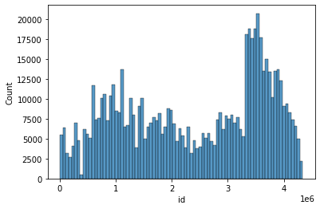

```python
sns.histplot(x=data["id"])
```

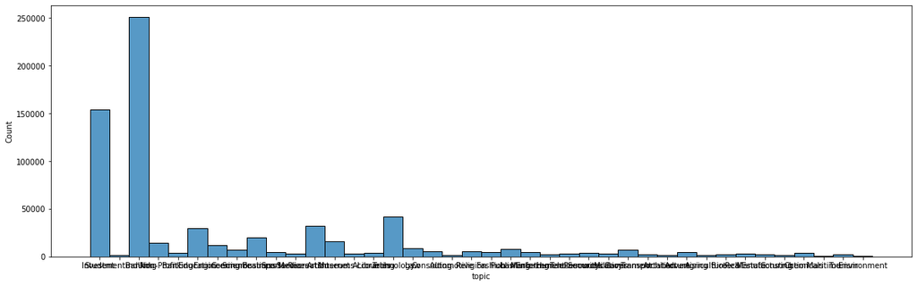

```python
plt.figure(figsize=(20,6))
sns.histplot(data["topic"])
```

```python
data["topic"].value_counts()
```

```
indUnk                     251015
Student                    153903
Technology                  42055
Arts                        32449
Education                   29633
Communications-Media        20140
Internet                    16006
Non-Profit                  14700
Engineering                 11653
Law                          9040
Publishing                   7753
Science                      7269
Government                   6907
Consulting                   5862
Religion                     5235
Fashion                      4851
Marketing                    4769
Advertising                  4676
BusinessServices             4500
Banking                      4049
Chemicals                    3928
Telecommunications           3891
Accounting                   3832
Military                     3128
Museums-Libraries            3096
Sports-Recreation            3038
HumanResources               3010
RealEstate                   2870
Transportation               2326
Manufacturing                2272
Biotech                      2234
Tourism                      1942
LawEnforcement-Security      1878
Architecture                 1638
InvestmentBanking            1292
Automotive                   1244
Agriculture                  1235
Construction                 1093
Environment                   592
Maritime                      280
Name: topic, dtype: int64
```

```python
t=data[data["id"]==data["id"].mode()[0]]
t
```

|  | id | gender | age | topic | sign | date | text |
| --- | --- | --- | --- | --- | --- | --- | --- |
| 235798 | 449628 | male | 34 | indUnk | Aries | 31,July,2002 | update i've added links to other web... |
| 235799 | 449628 | male | 34 | indUnk | Aries | 25,July,2002 | welcome to get that job! this is the... |
| 235800 | 449628 | male | 34 | indUnk | Aries | 30,August,2002 | viva la library! your local public l... |
| 235801 | 449628 | male | 34 | indUnk | Aries | 29,August,2002 | credential files: make your transcript... |
| 235802 | 449628 | male | 34 | indUnk | Aries | 23,August,2002 | urllink university of cincinnati care... |
| ... | ... | ... | ... | ... | ... | ... | ... |
| 240014 | 449628 | male | 34 | indUnk | Aries | 01,August,2004 | this past wednesday i went on an ... |
| 240015 | 449628 | male | 34 | indUnk | Aries | 01,August,2004 | a parent wrote into the q&a forum... |
| 240016 | 449628 | male | 34 | indUnk | Aries | 01,August,2004 | ireneq, the urllink official blog... |
| 240017 | 449628 | male | 34 | indUnk | Aries | 01,August,2004 | i often like to post to remind my... |
| 240018 | 449628 | male | 34 | indUnk | Aries | 01,August,2004 | this morning jennie, keisha, and ... |

4221 rows × 7 columns

```python
data["id"].mode()
```

```
0    449628
dtype: int64
```

There is this one particular user with the id 449628 that has written so many blogposts i.e. 4221. Now, let us check what are all the topics that are being dealt with that particular user.

As the link provided in the problem statement indicates, there is one another topic that is repeating i.e. has maximum mode.

Let us now check how the longer posts are structured, whether they might carry any useful information for the sake of tokenization and classification. As usual, we need to have fixed size for Word vector Transformation. So, for that reason we will fix it to the maximum size once we are confirmed that we aren't missing out on a lot of data while we are dropping. Other dropping the outlier data, we have no other way to deal with classification material. Usually it is desirable to have retention of last certain number of words within the blog, as it contains summary of the whole blog and is likely to help in classification. For that matter, we need to have a close look at some of the longer posts to check if there is any kind of pattern to it, or any kind of way in which it can be salvaged.

So, lets dive in.

```python
print(t.gender.unique())
print(t.age.unique())
print(t.topic.unique())
```

```
['male']
[34]
['indUnk']
```

```python
k=data[data["topic"]=="Student"]
k
```

|  | id | gender | age | topic | sign | date | text |
| --- | --- | --- | --- | --- | --- | --- | --- |
| 0 | 2059027 | male | 15 | Student | Leo | 14,May,2004 | info has been found (+/- 100 pages,... |
| 1 | 2059027 | male | 15 | Student | Leo | 13,May,2004 | these are the team members: drewe... |
| 2 | 2059027 | male | 15 | Student | Leo | 12,May,2004 | in het kader van kernfusie op aarde... |
| 3 | 2059027 | male | 15 | Student | Leo | 12,May,2004 | testing!!! testing!!! |
| 97 | 3668238 | female | 17 | Student | Gemini | 30,June,2004 | http://www.uploadimages.net/i... |
| ... | ... | ... | ... | ... | ... | ... | ... |
| 681279 | 1713845 | male | 23 | Student | Taurus | 01,July,2004 | dear susan, i could write some really ... |
| 681280 | 1713845 | male | 23 | Student | Taurus | 01,July,2004 | dear susan, 'i have the second yeast i... |
| 681281 | 1713845 | male | 23 | Student | Taurus | 01,July,2004 | dear susan, your 'boyfriend' is fuckin... |
| 681282 | 1713845 | male | 23 | Student | Taurus | 01,July,2004 | dear susan: just to clarify, i am as... |
| 681283 | 1713845 | male | 23 | Student | Taurus | 01,July,2004 | hey everybody...and susan, you might a... |

153903 rows × 7 columns

```python
print(k.gender.unique())
print(k.age.unique())
print(k.id.value_counts())
```

```
['male' 'female']
[15 17 14 25 23 36 16 24 13 27 26 45 37 34 35 38 39 33 41 48 43 47 42]
1107146    2237
1784456    1843
955372     1771
988941     1542
780903     1337
           ...
4294564       1
4140230       1
3866794       1
4291699       1
4173253       1
Name: id, Length: 5120, dtype: int64
```

```python
k[k.id==k.id.value_counts().index[0]]
```

|  | id | gender | age | topic | sign | date | text |
| --- | --- | --- | --- | --- | --- | --- | --- |
| 609212 | 1107146 | female | 16 | Student | Libra | 02,July,2004 | lindsey, we're 14, not thirteen. we're ... |
| 609213 | 1107146 | female | 16 | Student | Libra | 02,July,2004 | joah. god i hate you. |
| 609214 | 1107146 | female | 16 | Student | Libra | 02,July,2004 | just for the record... rosie nor i said... |
| 609215 | 1107146 | female | 16 | Student | Libra | 02,July,2004 | *laughs insanely* josh!! you had better... |
| 609216 | 1107146 | female | 16 | Student | Libra | 02,July,2004 | ok, some ground rules... any of my inv... |
| ... | ... | ... | ... | ... | ... | ... | ... |
| 611444 | 1107146 | female | 16 | Student | Libra | 26,July,2004 | dudes. i would publish mine b... |
| 611445 | 1107146 | female | 16 | Student | Libra | 05,August,2004 | as for the first one, certain... |
| 611446 | 1107146 | female | 16 | Student | Libra | 04,August,2004 | ok, so i was just thinking, a... |
| 611447 | 1107146 | female | 16 | Student | Libra | 01,August,2004 | well here you go; something ... |
| 611448 | 1107146 | female | 16 | Student | Libra | 01,August,2004 | ok, seriously people, someone... |

2237 rows × 7 columns

I have no idea what indUnk means but it seems to include a whole bunch of things that are not related. One single person, given by one single id, can't make 4221 posts. That's approximatley 11.5 years of atleast one post per day.

```python
data["id"].mode()[0]
```

```
449628
```

```python
temp=data["text"][15000]
print(temp)
```

```
             update!!! ran out of gas, so while its cooling down for refuel i come in to get a glass of tea and take some benadryl (the allergenic horrors out there!), and while sitting at my pc i see blood drops on my shirt, look at my wrist rest and find a blood stain pooling... somehow i cut my w…
```

```python
r=[]
for each in data["text"]:
    r.append(len(each))
r=pd.Series(r)
```

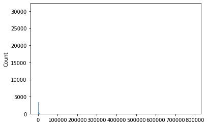

```python
sns.histplot(r)
```

```python
biggest_entry=data.iloc[r.nlargest(10).index[8]]
biggest_entry["text"]
```

```
"       ranted: june 11th 2004 feeling:sleepy well its 5 in the morning.. i spent most of my night crying over abused animals in slaughter houses.. yah i watched the videos.. for.. an hour.. and i was pretty upset.. ugh.. okay i cant keep typing about it i'll start crying again .. eh hem.. yes.. i h…
```

```python
p=biggest_entry["text"].split(".")
p
```

```
['       ranted: june 11th 2004 feeling:sleepy well its 5 in the morning',
 '',
 ' i spent most of my night crying over abused animals in slaughter houses',
 '',
 ' yah i watched the videos',
 '',
 ' for',
 '',
 ' an hour',
 '',
 ' and i was pretty upset',
 '',
 ' ugh',
 '',
 " okay i cant keep typing about it i'll start crying again ",
 '',
 ' eh hem',
 '',
 ' yes',
 '',
 ' i have a feeling i wont be hanging out with stacey considering',
 '',
 " i've barely slept tonight",
 '',
 'i also cant sleep because there was a huge spider in the bathroom and i woke up my mom to take it outside and when i came back it was gone',
 '',
 ' and i was worried i was gonna fall asleep and have it crawl into my mouth or sit on it or something',
 '',
 ' so i was half awake',
 '',
 ' and then finally i fully woke up at 4 30',
 '',
 ' and now here i am',
 '',
 ' uggh im so fucking bored',
 '',
 'a nd i wannna sleep because my eyes are burning but im too afraid',
 ' i donno how or wheni got so afraid of spiders',
 '',
 ' but apparently im quite afraid of them',
```

[output cut: 946 more lines]

```
 ' and it ugh i dont even know what to say about it',
 '',
 ' its just so frustrating',
 '',
 ' *sigh* but anyways',
 '',
 ' lately ive been feeling quite lonely',
 '',
 ' and i have no idea why',
 '',
 " stacey thinks i shouldnt be wanting or looking for a boyfriend in the first place because i'll just end up getting screwed over again",
 '',
 ' which is probably true',
 '',
 ...]
```

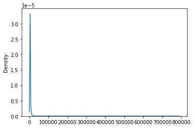

```python
sns.kdeplot(r)
```

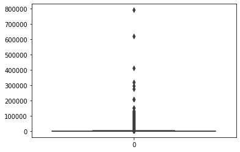

```python
sns.boxplot(data=r)
```

Now we will see how and why there are outliers for word count in so different ways. It is very important to realize if there is any salvage that can be made. Though it is required to go into significant detail to identify the distribution and whole bunch of other factors for patterns and identify information. It is just touched upon but not considered for the final cut.

```python
r.describe()
df=data.loc[(r<r.describe()["75%"]) & (r>r.describe()["25%"])]
```

```python
df.head()
```

|  | id | gender | age | topic | sign | date | text |
| --- | --- | --- | --- | --- | --- | --- | --- |
| 4 | 3581210 | male | 33 | InvestmentBanking | Aquarius | 11,June,2004 | thanks to yahoo!'s toolbar i can ... |
| 6 | 3581210 | male | 33 | InvestmentBanking | Aquarius | 10,June,2004 | somehow coca-cola has a way of su... |
| 9 | 3581210 | male | 33 | InvestmentBanking | Aquarius | 09,June,2004 | i surf the english news sites a l... |
| 13 | 3581210 | male | 33 | InvestmentBanking | Aquarius | 09,June,2004 | there is so much that is differen... |
| 16 | 3581210 | male | 33 | InvestmentBanking | Aquarius | 09,June,2004 | urllink wonderful oh-gyup-sal... |

```python
c=r[r>r.describe()["75%"]]
c
```

```
2         25467
5          3695
7          2281
8          2289
10         1767
          ...
681160     2787
681162     3462
681205     1569
681222     1716
681262     1634
Length: 170276, dtype: int64
```

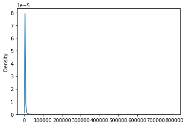

```python
sns.kdeplot(c)
```

```python
c.describe()
```

```
count    170276.000000
mean       2981.411297
std        4078.160082
min        1408.000000
25%        1751.000000
50%        2271.000000
75%        3279.000000
max      790123.000000
dtype: float64
```

```python
c.nlargest(25)
```

```
529872    790123
302666    620448
658665    411850
31751     321278
384759    295127
632880    274796
465417    207704
589853    207078
401258    149736
275622    149709
466150    131862
632902    128462
103745    127355
440565    126168
649410    125024
205679    122228
192230    121862
16759     119813
576270    112846
112308    107585
668267    104801
592587    100146
282726     92889
597096     92820
612722     92767
dtype: int64
```

```python
d=c[c>c.describe()["75%"]]
d
```

```
2         25467
5          3695
19         4521
27         5288
29         4778
          ...
681014    10700
681016    16048
681025     4631
681128     3595
681162     3462
Length: 42549, dtype: int64
```

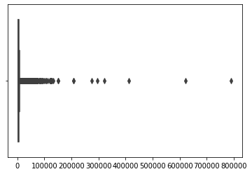

```python
sns.boxplot(d)
```

```python
d.nlargest(150)
```

```
529872    790123
302666    620448
658665    411850
31751     321278
384759    295127
           ...
569888     34683
146349     34446
570033     34318
570034     34316
371874     34137
Length: 150, dtype: int64
```

```python
e=d[d>d.describe()["75%"]]
e
```

```
2         25467
48        11101
219        9432
508       11182
577        6260
          ...
680937    15983
680944    14248
680986    16061
681014    10700
681016    16048
Length: 10635, dtype: int64
```

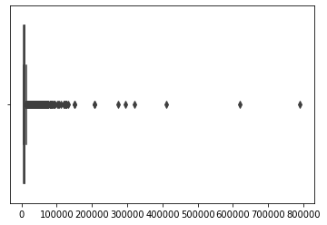

```python
sns.boxplot(e)
```

```python
e.describe()
```

```
count     10635.000000
mean      10017.670052
std       14072.682236
min        5879.000000
25%        6550.500000
50%        7638.000000
75%        9928.000000
max      790123.000000
dtype: float64
```

```python
df_len=[]
for each in df.text:
    df_len.append(len(each))
df_len=pd.Series(df_len)
```

```python
df_len.describe()
```

```
count    339930.000000
mean        694.070606
std         329.971156
min         231.000000
25%         405.000000
50%         637.000000
75%         951.000000
max        1406.000000
dtype: float64
```

I am sure something could be done but that is way too much time consuming and beyond my capacity alone. So, it is abandoned here.

### Word Processing and Cleanup

From here we can start our word vector embedding. But there is a problem here. We have not taken out stop words or anything like that regarding punctuation and a whole bunch of other things. So, first we have to take them out and then start with all this analysis. So, for that we will take up the function that is already defined and taken up somewhere (respectfully copied from Kaggle and else where), and try to process it using that particular function.

### Checking on tokenization and working

```python
nltk.download('stopwords')
from string import punctuation
from nltk.corpus import stopwords
from nltk import word_tokenize

stop_words = stopwords.words('english') + list(punctuation)
#print(punctuation)
def tokenize(text):
    words = word_tokenize(text)
    words = [w.lower() for w in words]
    return [w for w in words if w not in stop_words and not w.isdigit()]
```

**Plan** The plan here thus is to to create a vector of the dimensions 1406 (or something similar depending upon vocabulary) .We then use it for classifier model of Sklearn. Before that we combine and create all the labels of a particular blog into one, and make a one hot encoding of that particular labels.

```python
tokens=tokenize(data.loc[45].text)
print(tokens)
```

```
['urllink', 'korea', 'times', 'business', 'section', 'editorial', 'speaks', 'jwa', 'seung-hee', "'s", 'president', 'economic', 'research', 'institute', 'federation', 'korean', 'industries', 'mysteries', 'korean', 'economy', 'western-style', 'economic', 'reform', 'eroded', 'dynamism', 'korean', 'econ…
```

Looks like we have to run some Bigrams and trigrams across the text corups here. All the text columns, together here create the corpus.

```python
from nltk.collocations import BigramCollocationFinder
from nltk.metrics import BigramAssocMeasures

bigram_finder = BigramCollocationFinder.from_words(tokens)
bigrams = bigram_finder.nbest(BigramAssocMeasures.chi_sq, 50)
```

```python
print(bigrams)
```

```
[('10-16', 'hours'), ('academies', 'n.i.m.f.t'), ('add', 'cultural'), ('always', 'compare'), ('amid', 'sloganeering'), ('another', 'interesting'), ('attitude', 'toward'), ('business', 'section'), ('business/economic', 'list'), ('child', 'restraint'), ('chung-hee', '’'), ('clean', 'air'), ('communiti…
```

It is to be noted that Bigrams hold significant importance when dealing with technical literature, especially the continuity of the words is of primal importance when analyzing things and making sense. Hence, I decided to abandon this idea and go with other important trivial things in the original placement. But not before exploring it a little.

### Checking Stemming, POS tagging and Lemmatization

```python
from nltk.stem import PorterStemmer
from nltk.stem import WordNetLemmatizer
stemmer = PorterStemmer()
lemmatizer=WordNetLemmatizer()
tokens=word_tokenize(data.loc[45].text) #testing for one particular text

stemmed_tokens=[stemmer.stem(word) for word in tokens if word not in stop_words and not word.isdigit()]
stemmed_tokens
```

```
['urllink',
 'korea',
 'time',
 'busi',
 'section',
 'editori',
 'speak',
 'jwa',
 'seung-he',
 "'s",
 'presid',
 'econom',
 'research',
 'institut',
 'feder',
 'korean',
 'industri',
 'mysteri',
 'korean',
 'economi',
 'western-styl',
 'econom',
 'reform',
 'erod',
 'dynam',
 'korean',
 'economi',
 'seoul',
 'becom',
 'bigger',
 'bigger',
 'despit',
 'govern',
 "'s",
 'polici',
 'balanc',
 'region',
 'develop',
 'rural',
 'commun',
```

[output cut: 252 more lines]

```
 'seat',
 'without',
 'word',
 'signal',
 'stood',
 'togeth',
 'offer',
 'seat',
 'older',
 'folk',
 'unreal',
 'thing',
 'chang',
 'thing',
 'stay']
```

```python
lemmatized_words=[lemmatizer.lemmatize(word) for word in tokens if word not in stop_words and not word.isdigit()]
#
stemmed_tokens=[stemmer.stem(word) for word in lemmatized_words if word not in stop_words and not word.isdigit()]
print(len(stemmed_tokens))
stemmed_tokens
```

```
307
```

```
['urllink',
 'korea',
 'time',
 'busi',
 'section',
 'editori',
 'speak',
 'jwa',
 'seung-he',
 "'s",
 'presid',
 'econom',
 'research',
 'institut',
 'feder',
 'korean',
 'industri',
 'mysteri',
 'korean',
 'economi',
 'western-styl',
 'econom',
 'reform',
 'erod',
 'dynam',
 'korean',
 'economi',
 'seoul',
 'becom',
 'bigger',
 'bigger',
 'despit',
 'govern',
 "'s",
 'polici',
 'balanc',
 'region',
 'develop',
 'rural',
 'commun',
```

[output cut: 252 more lines]

```
 'seat',
 'without',
 'word',
 'signal',
 'stood',
 'togeth',
 'offer',
 'seat',
 'older',
 'folk',
 'unreal',
 'thing',
 'chang',
 'thing',
 'stay']
```

```python
lotr_pos_tags = nltk.pos_tag(lemmatized_words)
print(len(lemmatized_words))
lotr_pos_tags
```

```
307
```

```
[('urllink', 'VB'),
 ('korea', 'JJ'),
 ('time', 'NN'),
 ('business', 'NN'),
 ('section', 'NN'),
 ('editorial', 'NN'),
 ('speaks', 'NNS'),
 ('jwa', 'VBP'),
 ('seung-hee', 'NN'),
 ("'s", 'POS'),
 ('president', 'NN'),
 ('economic', 'JJ'),
 ('research', 'NN'),
 ('institute', 'NN'),
 ('federation', 'NN'),
 ('korean', 'JJ'),
 ('industry', 'NN'),
 ('mystery', 'JJ'),
 ('korean', 'JJ'),
 ('economy', 'NN'),
 ('western-style', 'JJ'),
 ('economic', 'JJ'),
 ('reform', 'NN'),
 ('eroded', 'VBD'),
 ('dynamism', 'JJ'),
 ('korean', 'JJ'),
 ('economy', 'NN'),
 ('seoul', 'VBD'),
 ('become', 'JJ'),
 ('bigger', 'JJR'),
 ('bigger', 'JJR'),
 ('despite', 'IN'),
 ('government', 'NN'),
 ("'s", 'POS'),
 ('policy', 'NN'),
 ('balanced', 'VBD'),
 ('regional', 'JJ'),
 ('development', 'NN'),
 ('rural', 'JJ'),
 ('community', 'NN'),
```

[output cut: 252 more lines]

```
 ('seat', 'NN'),
 ('without', 'IN'),
 ('word', 'NN'),
 ('signal', 'NN'),
 ('stood', 'VBD'),
 ('together', 'RB'),
 ('offered', 'VBN'),
 ('seat', 'NN'),
 ('older', 'JJR'),
 ('folk', 'NN'),
 ('unreal', 'JJ'),
 ('thing', 'NN'),
 ('change', 'NN'),
 ('thing', 'NN'),
 ('stay', 'NN')]
```

```python
nltk.download("maxent_ne_chunker")
nltk.download("words")
grammar = "NP: {<DT>?<JJ>*<NN>}"
#chunk_parser = nltk.RegexpParser(grammar)
#print(chunk_parser.parse(lotr_pos_tags))
tree = nltk.ne_chunk(lotr_pos_tags)
```

https://realpython.com/nltk-nlp-python/

```python
def extract_ne(quote):
    words = word_tokenize(quote, language="english")
    tags = nltk.pos_tag(words)
    tree = nltk.ne_chunk(tags, binary=True)
    return set(" ".join(i[0] for i in t) for t in tree if hasattr(t, "label") and t.label() == "NE")

extract_ne(data.loc[45].text)
```

```
{'u.s.'}
```

Just a quick jump into ngram ideas and checking for some collocations. It will be of vital importance if we are trying to summarize things or if we are using these in GANs.

```python
new_text=nltk.Text(lemmatized_words)
new_text.collocations() #Checking some collocations here.
```

```
despite policy; overseas study; development rural; n't seem; older
folk; policy promoting; many korean; korean economy; korea korean
```

```python
import nltk
from nltk.corpus import stopwords
from nltk.stem import PorterStemmer
from nltk.tokenize import WordPunctTokenizer


def get_bigrams(tokens):
    from nltk.collocations import BigramCollocationFinder
    from nltk.metrics import BigramAssocMeasures

    bigram_finder = BigramCollocationFinder.from_words(tokens)
    bigrams = bigram_finder.nbest(BigramAssocMeasures.chi_sq, 500)

    for bigram_tuple in bigrams:
        x = "%s %s" % bigram_tuple
        tokens.append(x)

    result = [' '.join([w for w in x.split()]) for x in tokens if len(x) > 8]
    return result
```

```python
get_bigrams(word_tokenize(data.loc[45].text))
```

```
['editorial',
 'seung-hee',
 'president',
 'institute',
 'federation',
 'industries',
 'mysteries',
 'western-style',
 'government',
 'development',
 'community',
 'promoting',
 'development',
 'communities',
 'disparity',
 'promoting',
 'egalitarianism',
 'redistributive',
 'competitiveness',
 'companies',
 'concentration',
 'concentration',
 'increased',
 'government',
 'standardize',
 'government',
 'sloganeering',
 'financial',
 'liberalization',
 'administration',
 'chung-hee',
 'development',
 'government',
 'strengthened',
 'corporate',
 'competitiveness',
 'business/economic',
 'mysteries',
 'grandparents',
 'academies',
```

[output cut: 317 more lines]

```
 'the promise',
 'the rodeo',
 'the sanctity',
 'the silicon',
 'the subway',
 'overseas to',
 'seats and',
 'children ,',
 'koreans have',
 'competitiveness .',
 'country .',
 'policies .',
 'competitiveness of',
 'concentration of',
 'of balanced']
```

# Model Development and Examination

**Plan of Action/Intent followed from here on**

Now the path is clear here. It is described step by step here.

Step 1. Word Vectorize the Given text, considering each entry of the text column to be an individual file in the corpus of texts. Case Conversion is taken.

Step 2. Keep a word limit, decided by the length of the text column in use. So, the extremities i.e. very short texts and extremely long texts, that fall under the "outlier" category are eliminated. (Here the elimination of outliers happened before tokenization has been done because it doesn't make much difference either way because special characters are equally distributed across the text in proportion to their total size)

Step 3. Take out Part of Speech Tagging. Then go for RegexParser and Chunk the phrases into one single word in the word vectorizer. Create a finished list ready for reference.

Step 4. Lemmatize the word list, followed by stemming of the words to eliminate any probable repetetitions, or variations of the same root word. All the while excluding the words if they are in our reference word list.

Step 5 (skipped here). We check for any Concordance (which is skipped here), and also check for n-gram data for Qualitative analysis and summary. Though it is useful to see it, it is not being used here since here it is a simple classification problem and not a GAN.

Step 6. Either use CBOW or other glove method to convert it appropriate vector size. I am planning to use tf_idf method since the significance of continuity in the model is not that important because they are extremely short texts. We can easily replace it with Count Vectorizer too.

Step 7. Club all the labels into a single label and use label binarizer to do multi-class prediction to the core.

Step 8. Create models based on various multi-class classifiers and then input the sparse vectors of the previous step and use them to solve the problem.

```python
class tfidf_vectors():

    ######################################################
    # Initializing the class function
    ######################################################

    def __init__(self,df_text_corpus):
        ############################################
        ############################################
        import nltk
        from string import punctuation
        from nltk.corpus import stopwords
        nltk.download('stopwords')
        self.stop_words = stopwords.words('english') + list(punctuation)
        ############################################
        ############################################
        self.corpus=df_text_corpus
        self.ind=df_text_corpus.index
        self.named_entities=[]
        self.vocabulary=[]
        self.word_index=None
        self.preprocess_token()
        self.vocabulary_build()
        self.tfidf=None
        #self.y=df_predictors

    ######################################################
    #End of Function
    ######################################################

    ######################################################
    # Pre-Process to create tokens of the data.
    ######################################################
    def preprocess_token(self):
        from nltk import word_tokenize
        import string
        corpus_out=[]
        named_entities=[]
        for text in self.corpus:
            words = word_tokenize(text)
            words = [w.lower() for w in words]
            #print("----------------------")
            tokens = [w for w in words if w not in stop_words and not w.isdigit()]
            tokens = [w for w in tokens if any(c for c in w if c in string.ascii_letters)]
            #print(tokens)
            for t in tokens:
                #print(t)
                if type(t)!=str:
                    _=tokens.pop(t)
                    print(_)
            pure_tokens=self.preprocess_text(tokens)
            corpus_out.append(pure_tokens)
            #for t in pure_tokens:
                #print(t)
                #if type(t)!=str:
                    #_=tokens.pop(t)
                    #print(_)
            #print("\n\nHere\n\n")
            #print("----------------------")
            #print(pure_tokens)
            temp=list(self.extract_ne(tokens))
            #print("----------------------")
            #print("")
            #print("----------------------")
            if len(temp)!=0:
                for word in temp:
                    named_entities.append(word)
            else:
                temp=None
        #print(named_entities)
        self.named_entities=list(set(named_entities))
        #print("----------------------")
        #print("named_entities gathered")
        #print("----------------------")
        #print(self.named_entities)
        #print("----------------------")
        self.corpus=pd.Series(corpus_out)
        #print("----------------------")
        #print("self.corpus")
        #print("----------------------")
        #print(self.corpus)
    ######################################################
    # End of Function
    ######################################################

    ######################################################
    # Extracting Named Entities that lies in a list and is excepted from lemmatization and stemming
    ######################################################

    def extract_ne(self,text_tokens):
        ############################################
        ############################################
        import nltk
        ############################################
        ############################################
        tags = nltk.pos_tag(text_tokens)
        tree = nltk.ne_chunk(tags, binary=True)
        return set(" ".join(i[0] for i in t) for t in tree if hasattr(t, "label") and t.label() == "NE")

    ######################################################
    #End of Function
    ######################################################

    ######################################################
    # Proper Word conditioning with Lemmatization and Stemming
    ######################################################

    def preprocess_text(self,tokens):
        ############################################
        ############################################
        from nltk.stem import PorterStemmer
        from nltk.stem import WordNetLemmatizer
        ############################################
        ############################################
        stemmer = PorterStemmer()
        lemmatizer=WordNetLemmatizer()
        lemmatized_words=[lemmatizer.lemmatize(word) for word in tokens if word not in self.stop_words and not word.isdigit()]
        stemmed_tokens=[stemmer.stem(word) for word in lemmatized_words]
        return stemmed_tokens

    ######################################################
    # End of Function
    ######################################################

    ######################################################
    # Building Vocabulary for tokenization so that proper vectors can be prepared.
    ######################################################

    def vocabulary_build(self):
        vocabulary = []
        for blog in self.corpus:
            #print("\n\nblog\n\n")
            for words in blog :
                if words not in vocabulary:
                    vocabulary.append(words)
        #print("----------------------")
        #print("printing Vocabulary")
        #print("----------------------")
        #print(vocabulary)
        for each_word in self.named_entities:
            print("----------------------")
            print("self.named_entities.each_word")
            print("----------------------")
            print(each_word)
            if each_word not in vocabulary:
                print("----------------------")
                print("new word added")
                print("----------------------")
                vocabulary.append(each_word)
        #print("----------------------")

        self.vocabulary=list(set(vocabulary))
        self.word_index = {w: index for index, w in enumerate(vocabulary)}
        #print("----------------------")
        #print("Printing self.word_index and self.vocabulary")
        #print("----------------------")
        #print(self.vocabulary)
        #print("----------------------")
        #print(self.word_index)
        print("The Length of the Vocabulary is :",len(self.vocabulary))
        print("The Number of Total Documents is :",len(self.corpus))

    ######################################################
    # End of Function
    ######################################################

    ######################################################
    # Model Fitting for TFIDF Vectorizer
    ######################################################

    def train_vectorizer(self,ratio=None,y=None):
        ############################################
        ############################################
        from sklearn.feature_extraction.text import TfidfVectorizer
        from sklearn.model_selection import train_test_split
        ############################################
        ############################################
        tfidf = TfidfVectorizer(stop_words=self.stop_words, vocabulary=self.vocabulary)
        self.corpus=self.corpus.apply(lambda x: " ".join(x))
        if ratio is not None:
            print(ratio)
            try :
                print(not y is None)
                assert not y is None,"y is not provided"
                print(y)
                self.X_train, self.X_test, self.y_train, self.y_test = train_test_split(self.corpus,y,
                                                                        test_size=ratio, random_state=0)
                tfidf.fit(self.X_train)
            except AssertionError as msg:
                print("Please provide the y for the ratio split to work",msg)
        else :
            tfidf.fit(self.corpus)
        self.tfidf=tfidf

    ######################################################
    # End of Function
    ######################################################

    ######################################################
    # Vector Transformation of the inputs
    ######################################################

    def transform(self,text_tokens):
        if self.tfidf is not None:
            return self.tfidf.transform(text_tokens)
        else:
            raise AssertionError("Module not yet Trained")

    ######################################################
    # End of Function
    ######################################################
vect=tfidf_vectors(df.text[:10000])
```

```
----------------------
self.named_entities.each_word
----------------------
mr. mrs.bennet
----------------------
new word added
----------------------
----------------------
self.named_entities.each_word
----------------------
u.s.a.
----------------------
self.named_entities.each_word
----------------------
u.s.
----------------------
self.named_entities.each_word
----------------------
mr.
----------------------
self.named_entities.each_word
----------------------
u.n.
The Length of the Vocabulary is : 41140
The Number of Total Documents is : 10000
```

```python
######################################################
# Function for proper classification labels
######################################################

def y_labels(dataframe,exceptions=None):
    exception_cols=exceptions
    if exceptions is None:
        exception_cols=[]
    df2=dataframe.copy()
    df=dataframe
    cols=[col for col in df.columns if col not in exception_cols]
    print(cols)
    df=df.drop(columns=cols,axis=1)
    df2=df2.drop(columns=exception_cols,axis=1)
    for each in cols:
        df2[each]=df2[each].astype(str)
    df["labels"]=df2.apply(lambda x : [x[col] for col in cols],axis=1)
    df=df.drop(columns=exceptions,axis=1)
    return df

######################################################
# End of Function
######################################################

y=y_labels(df[:10000],exceptions=["text","id","date"])
```

```
['gender', 'age', 'topic', 'sign']
```

```python
vect.corpus # A brief look at our corpus
```

```
0       [thank, yahoo, 's, toolbar, 'captur, url, popu...
1       [somehow, coca-cola, way, sum, thing, well, ea...
2       [surf, english, news, site, lot, look, tidbit,...
3       [much, differ, anyth, 've, ever, seen, well, n...
4       [urllink, wonder, oh-gyup-s, favorit, pork, re...
                              ...
9995    [quit, sometim, sinc, post, serious, noth, per...
9996    [bore, usual, anyway, ca, n't, chang, blog, 's...
9997    [anyway, pleas, 's, offenc, post, 's, feel, 'm...
9998    [mean, much, indi, could, get, n't, commerci, ...
9999    [beyblade.com, beyblad, rip, zone, tournament,...
Length: 10000, dtype: object
```

We are actually training the vectorizer along with splitting for future classification

```python
vect.train_vectorizer(ratio=0.15,y=y) #looking at how our multi-labels turned out
```

```
0.15
True
                                        labels
4      [male, 33, InvestmentBanking, Aquarius]
6      [male, 33, InvestmentBanking, Aquarius]
9      [male, 33, InvestmentBanking, Aquarius]
13     [male, 33, InvestmentBanking, Aquarius]
16     [male, 33, InvestmentBanking, Aquarius]
...                                        ...
21153              [male, 15, Student, Taurus]
21159              [male, 15, Student, Taurus]
21162              [male, 15, Student, Taurus]
21166              [male, 17, Student, Taurus]
21178           [male, 17, Student, Capricorn]

[10000 rows x 1 columns]
```

Just making a small picture to see the perfect combination of the cleaned data, placed in a neat dataframe.

```python
#y["text"]=vect.corpus
```

**Note :** Now, the complete process is complete. If we ever want to entirely new data that is not out of the corpus, we can simply initialize it as a Pandas series and an object of tfidf_vector() here. Instead of using its own method (which will not work out anyway), we can directly use the corpus dgenerated as part of its initialization and use it for transformations and supply it further down the line for usage.

## Feature Selection & Classification Labeling

```python
from sklearn.feature_selection import SelectKBest, chi2
from sklearn.naive_bayes import MultinomialNB
from sklearn.preprocessing import MultiLabelBinarizer
from sklearn.multiclass import OneVsRestClassifier
from sklearn.linear_model import LogisticRegression
from sklearn.multiclass import OneVsOneClassifier
from sklearn.svm import LinearSVC

#
#
label_binarizer=MultiLabelBinarizer()
bayes = MultinomialNB()
ch2 = SelectKBest(chi2, k=10000) # Since total words are only 7000, it is quite useless
lr=LogisticRegression(solver='lbfgs',multi_class="ovr")
svc=LinearSVC(random_state=0)
#
#
######################################################
# Function to print Metrics
######################################################

def print_metrics(y_test,y_pred):
    ############################################
    ############################################
    from sklearn.metrics import accuracy_score, f1_score, average_precision_score, recall_score,classification_report
    ############################################
    ############################################
    print("F1 Score : ",f1_score(y_test,y_pred,average="weighted"))
    print('Average Precision Score : ',average_precision_score(y_test,y_pred,average="weighted"))
    print('Average Recall Score : ',recall_score(y_test,y_pred,average="weighted"))
    print(classification_report(y_test,y_pred))

######################################################
# End of Function
######################################################
```

```python
X_train = vect.transform(vect.X_train)
X_test = vect.transform(vect.X_test)
y_train = label_binarizer.fit_transform(vect.y_train["labels"])
y_test = label_binarizer.transform(vect.y_test["labels"])
```

```python
# Discarding some obviously useless words
X_train = ch2.fit_transform(X_train, y_train)
X_test = ch2.transform(X_test)
```

```python
clf= OneVsRestClassifier(svc,n_jobs=-1)
clf.fit(X_train, y_train)
svc_pred = clf.predict(X_test)
print_metrics(y_test,svc_pred)
```

```
F1 Score :  0.49350766310935507
Average Precision Score :  0.41421525205947357
Average Recall Score :  0.4171666666666667
              precision    recall  f1-score   support

           0       1.00      0.09      0.17        22
           1       1.00      0.19      0.32        78
           2       0.73      0.19      0.30        85
           3       0.89      0.28      0.42       120
           4       0.64      0.25      0.36       152
           5       0.92      0.25      0.40       142
           6       0.93      0.25      0.40       159
           7       0.75      0.08      0.14       114
           8       1.00      0.09      0.17        66
           9       0.66      0.25      0.36       185
```

[output cut: 70 more lines]

```python
clf2= OneVsRestClassifier(lr,n_jobs=-1)
#Hyperparameters above were taken from https://www.kaggle.com/sharat111/multilabelclassificationofblogauthor-completesoln
clf2.fit(X_train,y_train)
log_reg_pred=clf2.predict(X_test)
print_metrics(y_test,log_reg_pred)
```

```
F1 Score :  0.32599961980205466
Average Precision Score :  0.3283926896379176
Average Recall Score :  0.2848333333333333
              precision    recall  f1-score   support

           0       0.00      0.00      0.00        22
           1       1.00      0.04      0.07        78
           2       0.00      0.00      0.00        85
           3       1.00      0.07      0.14       120
           4       0.64      0.06      0.11       152
           5       1.00      0.07      0.13       142
           6       0.97      0.23      0.38       159
           7       0.00      0.00      0.00       114
           8       0.00      0.00      0.00        66
           9       0.80      0.02      0.04       185
```

[output cut: 70 more lines]

```python
clf3=OneVsRestClassifier(bayes,n_jobs=-1)
clf3.fit(X_train, y_train)
NB_pred = clf3.predict(X_test)
print_metrics(y_test,NB_pred)
```

```
F1 Score :  0.2688322121589061
Average Precision Score :  0.3053558727366636
Average Recall Score :  0.245
              precision    recall  f1-score   support

           0       0.00      0.00      0.00        22
           1       0.00      0.00      0.00        78
           2       0.00      0.00      0.00        85
           3       0.50      0.01      0.02       120
           4       0.00      0.00      0.00       152
           5       1.00      0.02      0.04       142
           6       0.88      0.04      0.08       159
           7       0.00      0.00      0.00       114
           8       0.00      0.00      0.00        66
           9       0.00      0.00      0.00       185
```

[output cut: 70 more lines]

```python
#clf4=OneVsOneClassifier(svc,n_jobs=-1)
#clf4.fit(X_train, y_train)
#svc_pred2 = clf4.predict(X_test)
#print("Accuracy for One Vs Rest Classifier with SVC Basis",accuracy_score(y_test, svc_pred2))
```

The Below code is copied form the Kaggle competitions given by the link below. https://www.kaggle.com/parvez218/multi-lable-classification

```python
import random

def print_predicted(y_predicted, y_test = y_test , n = 5):
    j = []
    for i in range(n):
        j.append(random.randint(0, len(y_test)))
    print(j)

    for k in j:
        print(label_binarizer.inverse_transform(y_predicted)[k])
        print(label_binarizer.inverse_transform(y_test)[k])
        print(vect.X_test.iloc[k])
        print("=================x==================x================x==========")
```

```python
print_predicted(y_predicted=log_reg_pred,y_test=y_test, n= 10)
```

```
[1316, 221, 1197, 943, 1431, 537, 1469, 1289, 583, 77]
('34', 'Sagittarius', 'female', 'indUnk')
('34', 'Sagittarius', 'female', 'indUnk')
fa-la-la-la-la christma card cooki hand-deliv work even littl book quot deliv 've busi littl diva also took girl brunch santa saturday nice gift one co-work actual saturday holiday day littl famili girl santa went mall money mom bought girl new outfit crowd bad unpleas sale good even got see special…
=================x==================x================x==========
('female', 'indUnk')
('24', 'Sagittarius', 'female', 'indUnk')
hair funer monday someon cut lock husband 's hair put open casket took scissor cut lock wife 's hair luckili n't see bodi littl hair left amazingli beauti perpetu curli black hair die lung cancer r.i.p 've never taken acid trip 'm go like peopl better beauti damn book p. n't know idm feel impend sen…
=================x==================x================x==========
('female',)
('27', 'Cancer', 'Education', 'female')
okay someon need time go shop citi otherwis go come home four leg friend sometim soon thursday night sad hot lop ear bunni night market yesterday basset hound puppi today beagl n't know enough self control bring one cute littl critter home go back night market soon get someth work dread littl friend…
=================x==================x================x==========
('male',)
('34', 'Education', 'Pisces', 'male')
playwrit oscar parti 'd like interupt regularli schedul program let playwrit alumnu 're invit rudd pm sunday night year prolif playwright come pleas pa word along peer 've lost contact peace~
=================x==================x================x==========
('female', 'indUnk')
('25', 'Gemini', 'Museums-Libraries', 'female')
continu amaz disrespect receiv customer-servic provid let make disclaim custom museum member absolut wonder noth exchang happi smile day long string peopl gotten angri wo n't break rule therefor berat increasingli rude rude person want someth get better faster nicer servic
=================x==================x================x==========
('female', 'indUnk')
('17', 'Gemini', 'Student', 'female')
final watch season final scrub funni guess want j.d elliott thing like ross rachel mayb year later final episod get togeth elliott fli pari someth haha sometim think take much grant peopl given much give back noth realli 's sad ugh ok tomorrow revis revis revis exam ahhh~
=================x==================x================x==========
('male',)
('16', 'Gemini', 'indUnk', 'male')
wow mani good thing happen past coupl day got gmail account thank uncl made gmail account msn account someth ive tri almost year ny mani time got access dvd burner backup cd get play around sun comput one know noth yet one problem sun though get 'ok prompt say 'ok type command none know frustrat com…
=================x==================x================x==========
('24', 'Aries', 'female', 'indUnk')
('24', 'Aries', 'female', 'indUnk')
emailalert=no email=adgr indiana.edu url=http //closeproximity.blogspot.com name=proxim bgcolor=003399 fcolor=ffffff link=ffffcc words=com title=com width=350 height=350 're look perfect vintag tee site urllink vintag vantag sleek websit lot goodi look includ fave urllink ask heather unrel note 've …
=================x==================x================x==========
('male',)
('15', 'Capricorn', 'Religion', 'male')
mento one popular refresh sweet town made contract apl secretari andrew week sponsorship apl andrew said glad see mento partner desper need realli releaved.i hope help cureent problem apl face
=================x==================x================x==========
('male',)
('35', 'Aries', 'Technology', 'male')
sadli think right solut wipe extremist happen must way get throught hatr prevent accept anyth total victori obl want sit middl desert preach hatr zionist lackey usa problem hatr cross line becom violent action see simpl matter surviv
=================x==================x================x==========
```

```python
print_predicted(y_predicted=svc_pred,y_test=y_test, n= 10)
```

```
[49, 423, 349, 505, 880, 483, 228, 405, 936, 1205]
('Cancer', 'indUnk', 'male')
('17', 'Gemini', 'Student', 'female')
urllink sourc urllink msn taiwan news haha music best yo
=================x==================x================x==========
('female', 'indUnk')
('17', 'Gemini', 'Student', 'female')
ok set post joey blog hmm half hour ago still havnt dun lol got distract makin seem pretti cool tho dont c 's gona read never get tire talkin went zoo face paint like lion roar joey took bday actuali dreadin night cri sunday night convinc someth bad wld happen alway last year major row sum1 end doin…
=================x==================x================x==========
('female',)
('14', 'Leo', 'female', 'indUnk')
man loyal faith christian trust lord everth walk beach repres life look back alway see set footprint one one lord world turn upsid parent die lost job got divors verg commit suicid look back sand saw one set footprint everyth calm talk god ask god left time trouble. nbsp god repli 'those set footpri…
=================x==================x================x==========
('female', 'indUnk')
('17', 'Scorpio', 'female', 'indUnk')
today feel anti-blog heard song radio remind everi song remind someon audit comedi rockhurst made callback yay met interest peopl took mind everyth els nice goodnight love
=================x==================x================x==========
('13', 'Student', 'female')
('13', 'Aquarius', 'Student', 'female')
manda u want yur page soo hear ure realli weird time alot said u ur awesom friend ur alway listenin crap say shit yur realli nice sweet ya soo mani good word say u ya im tire soo ill write u later mk xxx meg
=================x==================x================x==========
('male',)
('34', 'Education', 'Pisces', 'male')
sometim ok well honestli alot first arriv comput go blog check see wrote anyth new mani year train roll arrival-ding-of-incoming-email yet-develop cognit concept bloggeri
=================x==================x================x==========
('female',)
('25', 'Aries', 'BusinessServices', 'female')
distract need love strong power forc love love experi fulfil relationship falter around 's hard hope yet need remain natur yearn thing yet search object love left want wonder peopl find begin still need consum pray hear other speak need consum life pray consum mine pray balanc heav earthli oftern tw…
=================x==================x================x==========
('17', 'Scorpio', 'female', 'indUnk')
('17', 'Scorpio', 'female', 'indUnk')
today good day start last night hee hee rose dillon mous chantel ate lot lot lot chocol cake ca-ak newspap play question fun love newspap realli practic mass today sang lil heart sing make good mood unless 'm crappi mood giggl yesterday mr. thoma ask would journal practicum next year cool
=================x==================x================x==========
('27', 'Virgo', 'indUnk', 'male')
('13', 'Internet', 'Virgo', 'female')
jk antoni ok 's joke man watch tv wife ask fix stair look like 're gon na fall minut man say 'do plumber written fore head wife ask husbad fix sink repli 'do plumber written fore head frustrat wife ask husband replac oil car husband say 'do mechan written forehead mad wife man head bar littl arriv b…
=================x==================x================x==========
('female',)
('27', 'Taurus', 'female', 'indUnk')
sit next copier/scanner/faxer/printer/collater/ub coffe machin everi get see express peopl face tri use thing ca n't share joy peopl seem get angri everi time tri get pictur frustrat hmph
=================x==================x================x==========
```

**Note** I tried with this but it didn't work. I know where it is wrong. But I am short on time to deal with it. Please accept it with pity.

For the sake of dealing with it, I have dealt with additional types of classifier and bases just for the sake of dealing with it.

```python
from sklearn.multioutput import MultiOutputClassifier
from sklearn.multioutput import ClassifierChain
from sklearn.ensemble import RandomForestClassifier
#
#
forest = RandomForestClassifier(random_state=1)
multi_target_forest = MultiOutputClassifier(forest, n_jobs=-1)
multi_chain=ClassifierChain(forest,random_state=0)
#
#
multi_target_forest.fit(X_train,y_train)
multi_chain.fit(X_train,y_train)
#
#
forest_pred=multi_target_forest.predict(X_test)
chain_pred=multi_chain.predict(X_test)
#
#
print("Random Forest Base with Multiout Classifier")
print_metrics(y_test,forest_pred)
print("Random Forest Base with Classifier Chain")
print_metrics(y_test,chain_pred)
```

```
Random Forest Base with Multiout Classifier
F1 Score :  0.4339096168993488
Average Precision Score :  0.3915210231617833
Average Recall Score :  0.3521666666666667
              precision    recall  f1-score   support

           0       0.00      0.00      0.00        22
           1       1.00      0.15      0.27        78
           2       1.00      0.11      0.19        85
           3       1.00      0.16      0.27       120
           4       1.00      0.11      0.20       152
           5       0.95      0.29      0.44       142
           6       1.00      0.26      0.42       159
           7       0.83      0.04      0.08       114
           8       0.76      0.20      0.31        66
```

[output cut: 158 more lines]

```python
print_predicted(y_predicted=forest_pred,y_test=y_test, n= 10)
```

```
[64, 15, 1284, 979, 479, 862, 331, 1337, 1407, 1279]
('female', 'indUnk')
('25', 'Communications-Media', 'Pisces', 'male')
urllink hous arrest urllink season episod toni 's job stress absurdli juxtapos 'pressur face everyday schlub garbag busi lead anoth panic attack junior get old crusti choic made earli life make twilight littl excruci dr. melfi lose control life lose son toni drive liter drink feel intens need unders…
=================x==================x================x==========
('male',)
('36', 'Aries', 'Fashion', 'male')
favorit travel destin would say alaska like differ rule shortest distanc two point may straight line golf midnight sometim love everyth big grand unspoil would like go back big repeat travel would like go mani place difficult imagin time alaska hold special place heart get destin travel horror stori…
=================x==================x================x==========
('male',)
('27', 'Education', 'Virgo', 'male')
hell never felt comfort enough anyon realli tell first sexual experi 've ever bit problem first time peopl may even say n't give good first impress get know time chang mind find hard believ think actual confirm pompou as realiz rather harmless decid actual get without give damn without ado give hope…
=================x==================x================x==========
('female', 'indUnk')
('25', 'Cancer', 'female', 'indUnk')
emot drain day realli noth left could n't help fall love ca n't blame 'm one known done still hope guess n't understand someon could marri someon n't love love anyway 's stupid feel caus pain end even worth give away sometim take much work sustain peopl n't will abl go right feel like feel beyond re…
=================x==================x================x==========
('female',)
('13', 'Aquarius', 'Student', 'female')
hello yesterday saw anchorman pretti good consid saw best friend lizzi amanda glenna alex best friend couldnt make unfortun damn good movi yet kinda pointless mani way think manda got bore sinc eat whole time lol movi went liz 's hous chillax hung evil father tooo as make come home yet anoth fight t…
=================x==================x================x==========
('female',)
('16', 'Capricorn', 'Student', 'male')
topic bound come eventu might well get way nbsp favourit kind music moment nbsp nbsp favourit type music favourit band favourit song. nbsp note n't nbsp would nbsp classic rock aerosmith dust wind kansa
=================x==================x================x==========
('female',)
('13', 'Internet', 'Virgo', 'female')
hey peopl chang music site wonder load site well n't know 'meant live switchfoot want differ song tell realli want know load dial-up that say
=================x==================x================x==========
('male',)
('26', 'Sagittarius', 'indUnk', 'male')
nicknam think chri realli cool nicknam probabl n't even rememb name chri case n't know chri happi see nicknam work n't guy use post come good nicknam blake good nicknam marshal realli good one one stick happi comment
=================x==================x================x==========
('male',)
('23', 'Internet', 'Leo', 'male')
discuss bride 's name beep someon mention mayb cuss word repli could n't name movi could 've easili blood fuck blood spray fuck fuck kill fuck blood blood bill fuck yeh cuss okay
=================x==================x================x==========
('16', 'Cancer', 'Education', 'female')
('16', 'Cancer', 'Education', 'female')
went school today see chines sing competit hohoho~ kinda nyc ler scream bo voic fuish kesian charmain knee blue black cham betul still danc ler dengan gayanya akaka aihz form2z lyk fitnah ppl hm form2z alwiz lydat dun rememb fitnah- ppl form2 akaka~ hmm saw mun yin 's sister haha~ darn cute lar ahha…
=================x==================x================x==========
```

```python
print_predicted(y_predicted=chain_pred,y_test=y_test, n= 10)
```

```
[152, 587, 188, 1048, 690, 1371, 799, 1454, 998, 517]
('indUnk', 'male')
('24', 'Scorpio', 'female', 'indUnk')
frustrat part would n't know 'd predict aloud yul y'know funni thing start type call say 's way prize guess happen next
=================x==================x================x==========
('female', 'indUnk')
('35', 'Aries', 'Technology', 'male')
katherin blast first christma knew come childhood excit around hous boy clue anyth go like attent grand parent day in-law left spent day cri dramat drop poor juli home three
=================x==================x================x==========
('36', 'Aries', 'Fashion', 'male')
('36', 'Aries', 'Fashion', 'male')
know girlfriend laura love n'sync specif justin timberlak know know actual 's kind cute digress one ca n't stand hate littl afro way suddenli talk 'street 's around african-american folk cocki look-how-much-trim-i-can-get attitud 've forc listen choic cut latest album 'justifi center around peopl li…
=================x==================x================x==========
('female', 'indUnk')
('35', 'Aries', 'Technology', 'male')
thank encourag word advic know love step right direct 's easi field break feel like 'm paddl upstream sometim keep go 'caus n't choic give would keep charact may frustrat cri scream get angri think world unjust collect keep tri 'caus 's 'll fine trust colleg student moment self-doubt-induc panic
=================x==================x================x==========
('female', 'indUnk')
('25', 'BusinessServices', 'Sagittarius', 'male')
weekend someon stole ladi upstair garag door open van think person go tri come back open garag door come tri break hous go lock front door night 's go get new remot garag door open bother 's pain as worri lock etc plu 'll lock patio door 's bad ca n't let malcolm run free hous
=================x==================x================x==========
('female', 'indUnk')
('38', 'Internet', 'Sagittarius', 'female')
past week cold raini difficult emot work frustrat usual per previou post today bank holiday denmark make much need long week-end holiday whitsun anoth name pentecost held seventh sunday easter 's holiday number european countri weather gloriou last sunday ran 5k race lar ran 10k version race gotten …
=================x==================x================x==========
('35', 'Aries', 'Technology', 'male')
('35', 'Aries', 'Technology', 'male')
fallen prey angi 's quiz result outlet n't take crap anyon know 're fine good peopl drawn strength sometim come across somewhat blunt hurt n't afraid open other n't alway control urllink 's sign brought urllink quizilla
=================x==================x================x==========
('female', 'indUnk')
('23', 'Virgo', 'indUnk', 'male')
get back basic 'm go say blog mean freedom say whatev want write whatev want also mean get busi post anyth week bad 'm glad peopl check thing time time n't mean keep date note go post anonym forgot name password might well go ahead sign name bottom rule anyway thank interest everyon check back tri g…
=================x==================x================x==========
('indUnk', 'male')
('17', 'Virgo', 'indUnk', 'male')
urllink slashdot hydra vs. shredder quit interest show time live two comput play game like chess win/defeat begin end birth matrix know
=================x==================x================x==========
('indUnk', 'male')
('17', 'Capricorn', 'Student', 'male')
well complet anoth day toyl curri dungeon littlehampton said hard day toyl feel bit confid sell ware wahoo could smidg sarcasm could n't well frielfer say gone long bit chat holiday wasnt iv spoken properli anywho dog two head two bodi knock door dont answer may eat hob goblin also need speak fairwe…
=================x==================x================x==========
```

**Final Remarks**

Because of the frequent power disruptions at the time of finishing project and computational limitations placed upon me, I couldn't deal with the large corpus given to me, even after eliminating the outliers. I sincerely apologize.